# OTX2 case study — Fig 3g

Paper: Wang et al. *Nat. Genet.* **57**, 2772-2784 (2025) 10.1038/s41588-025-02350-8

> **Upstream / preprocessing.** FASTQ → BAM → bigwig, MACS2 peak calling, Xia 2019 / Zou 2022 / Gifford 2013 downloads, and the one-off xlsx → TSV extractions are all documented in `preprocess.ipynb`. This notebook starts from the cached inputs under `/scratch/users/steorra/data/otx2/`.

## 1 · Setup

```python
import os, pathlib, warnings
os.environ['PATH'] = '/scratch/users/steorra/env/omicdev/bin:' + os.environ.get('PATH', '')
warnings.filterwarnings('ignore', category=UserWarning)

import numpy as np
import pandas as pd
import matplotlib.pyplot as plt

import epione as epi
epi.pl.plot_set()

DATA         = pathlib.Path('/scratch/users/steorra/data/otx2')
OMIX         = DATA / 'OMIX006476'
ZOU          = DATA / 'GSE197265'
XIA          = DATA / 'GSE124718'
GIFFORD      = DATA / 'GSE61475'
SUPP_TABLES  = DATA / 'supp/supp_tables.xlsx'
GENCODE_GTF  = pathlib.Path('/scratch/users/steorra/data/hg19/gencode.v41lift37.annotation.gtf.gz')
```

[output not shown]

## 2 · Load distal peak sets for the three conditions

```python
peaks_4C = pd.read_csv(OMIX / 'h_OTX2_day2_CUTRUN_rep12_peaks.bed',
                       sep='\t', header=None,
                       names=['chrom','start','end','name','score'])
peaks_4C = peaks_4C[['chrom','start','end']].astype({'start':int,'end':int})
peaks_ESC = pd.read_csv(OMIX / 'H9_OTX2_ChIP_21Mcells_peaks.bed',
                          sep='\t', header=None, usecols=[0,1,2], names=['chrom','start','end'])
dec_dfs = []
for f in [GIFFORD/'GSM1505707_Otx2_022813_ecto.bed.peak.txt.gz',
            GIFFORD/'GSM1505710_Otx2_062613_ecto.bed.peak.txt.gz']:
    d = pd.read_csv(f, sep='\t', header=None, usecols=[0,1,2],
                     names=['chrom','start','end'], dtype={'chrom':str})
    d['chrom'] = 'chr' + d['chrom']
    dec_dfs.append(d)
peaks_dEC = pd.concat(dec_dfs, ignore_index=True)
print(f'4C={len(peaks_4C)}  ESC={len(peaks_ESC)}  dEC={len(peaks_dEC)}')
```

```
4C=45521  ESC=70126  dEC=30714
```

```python
# TSS annotation + distal peak filter via epi.utils.filter_distal_peaks
gtf = epi.utils.get_gene_annotation(str(GENCODE_GTF))
gtf['tss'] = np.where(gtf['strand']=='+', gtf['start'], gtf['end'])

distal_4C  = epi.utils.filter_distal_peaks(peaks_4C,  gtf[['chrom','tss']], min_distance=2500)
distal_ESC = epi.utils.filter_distal_peaks(peaks_ESC, gtf[['chrom','tss']], min_distance=2500)
distal_dEC = epi.utils.filter_distal_peaks(peaks_dEC, gtf[['chrom','tss']], min_distance=2500)
print(f'distal: 4C={len(distal_4C)} ESC={len(distal_ESC)} dEC={len(distal_dEC)}')
```

```
distal: 4C=41286 ESC=61892 dEC=22623
```

## 3 · Assign each peak to a cell-type cluster

`epi.utils.classify_peaks_by_overlap` attributes each peak to the first set in `primary_order` that contains it, then labels it with every set it overlaps — yielding a non-overlapping partition of the union across sets. With three sets we get up to 7 clusters (4C-specific, ESC-specific, dEC-specific, 4C/ESC shared, 4C/dEC shared, ESC/dEC shared, 4C/ESC/dEC shared).

```python
all_rows = epi.utils.classify_peaks_by_overlap(
    {'4C': distal_4C, 'ESC': distal_ESC, 'dEC': distal_dEC},
    primary_order=['4C','ESC','dEC'],
)
print(all_rows['cluster'].value_counts())
```

```
cluster
ESC-specific         43028
4C-specific          28209
dEC-specific         10081
4C/ESC shared         9722
ESC/dEC shared        5311
4C/ESC/dEC shared     2720
4C/dEC shared          635
Name: count, dtype: int64
```

## 4 · Compute per-bigwig matrices, then render

Three-step pipeline:

1. Adapt `all_rows` to the schema `compute_matrix_region` expects (`seqname`, `start`, `end`, `strand`, `gene_id`, `feature`).
2. Call `bw.compute_matrix_region(bw_name, ..., sort=False)` once per condition — returns an AnnData with the same row order as the input.
3. Pass `{bw_label: adata}` to `bw.plot_matrix_multi` together with the per-row cluster labels — it renders the multi-condition heatmap with the coloured cluster side-bar.

```python
bw = epi.bulk.bigwig({
    '4C':  str(OMIX    / 'h_OTX2_day2_CUTRUN_rep12_pmu_100bp_rpkm_bamCoverage.bw'),
    'ESC': str(OMIX    / 'H9_OTX2_ChIP_21Mcells_100bp_rpkm_bamCoverage.bw'),
    'dEC': str(GIFFORD / 'GSM1505707_Otx2_022813_ecto.bw'),
})
bw.read()

# Cap each cluster at 3000 peaks BEFORE scanning — the full table has
# ~100k distal peaks; without the cap every bw scan is ~2 min.
MAX_PER_CLUSTER = 3000
plot_rows = (all_rows.groupby('cluster', sort=False, group_keys=False)
                     .apply(lambda g: g.head(MAX_PER_CLUSTER))
                     .reset_index(drop=True))

# Adapt peaks -> compute_matrix_region's expected schema.
regions = plot_rows.rename(columns={'chrom':'seqname'}).copy()
regions['strand']  = '+'
regions['feature'] = 'transcript'
regions['gene_id'] = [f'peak_{i}' for i in range(len(regions))]

# Compute signal matrix per condition (sort=False keeps row order
# aligned with plot_rows / cluster labels). n_jobs parallelises
# across chromosomes.
matrices = {
    name: bw.compute_matrix_region(
        name, regions, nbins=120, upstream=3000, downstream=3000,
        anchor='center', sort=False, n_jobs=4)
    for name in ['4C','ESC','dEC']
}
print({k: v.shape for k,v in matrices.items()})
```

```
└─ Load bigWig files
  ├─ Loading 4C...
  ├─ Loading ESC...
  └─ Loading dEC...
  └─ Computing 4C matrix
```

```
  └─ 4C matrix finished
  └─ Computing ESC matrix
```

```
  └─ ESC matrix finished
  └─ Computing dEC matrix
```

[output not shown]

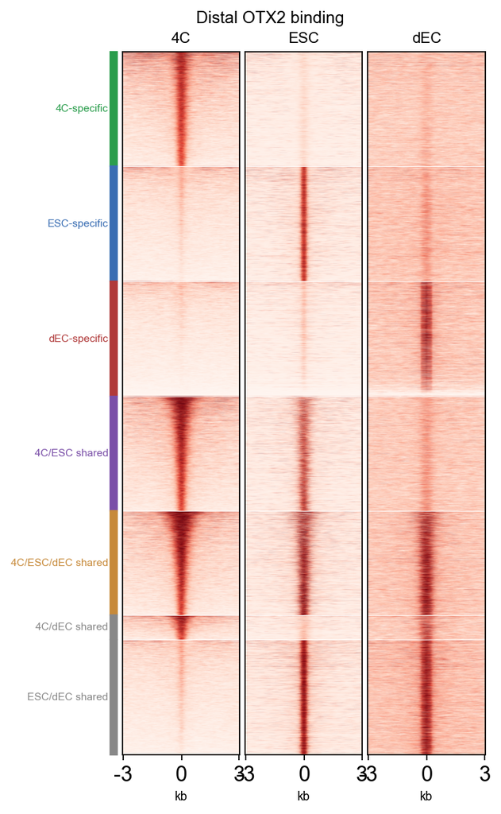

```python
fig, axes = bw.plot_matrix_multi(
    matrices,
    cluster_labels=plot_rows['cluster'],
    cluster_order=['4C-specific','ESC-specific','dEC-specific',
                   '4C/ESC shared','4C/ESC/dEC shared'],
    cluster_colors={'4C-specific':'#2A9D4C','ESC-specific':'#3A6EB3',
                    'dEC-specific':'#B03A3A','4C/ESC shared':'#7A4FA8',
                    '4C/ESC/dEC shared':'#C78A3A'},
    figsize=(4.2, 7.5), title='Distal OTX2 binding',
)
plt.show()
```